# Lecture 7: Probability

PSTAT100: Data Science - Concepts and Analysis

John Inston

johninston@ucsb.edu

University of California, Santa Barbara

September 1, 2026

## 🚁 Overview

### Aims of the lecture

- Understand what **models** are and why we build them.
- Distinguish between the **four categories of models**: deterministic, probabilistic, statistical, and machine learning.
- Recap **probability theory** foundations needed for statistical modelling:
  - Random variables and distributions.
  - Expectation and variance.
  - Conditional probability and conditional expectation.
  - Key standard distributions.

### 📚 Required Libraries

In this lecture we will be using the following libraries:

```python
import numpy as np
import matplotlib.pyplot as plt
import seaborn as sns
from scipy import stats
from scipy.stats import binom, norm, multivariate_normal
```

### 💅 Figure Styles

```python
sns.set_style('whitegrid')
sns.set_palette('Set2')
```

# Introduction to Modelling

## 🧮 What is a Model?

### The idea of a model

**Model**

A **model** is a simplified, mathematical representation of a real-world system or process. It captures the essential features of the system while abstracting away unnecessary detail.

### Examples of models in data science

- A **regression equation** predicting house prices from square footage.
- A **probability distribution** describing the heights of adult males.
- A **decision tree** classifying emails as spam or not-spam.
- A **differential equation** modelling the spread of a disease.

### A key trade-off

- All models are wrong — but some are **useful** (Box, 1979).
- A good model is **simple enough** to understand and **accurate enough** to be informative.

## Why Build Models?

### Reasons for modelling

- **Understand**: Reveal the relationships and mechanisms underlying observed data.
- **Predict**: Forecast future or unobserved outcomes from observed inputs.
- **Infer**: Draw conclusions about **populations** from **samples** (statistical inference).
- **Simulate**: Study hypothetical scenarios and their consequences.
- **Communicate**: Express complex patterns in data concisely and precisely.

## Categories of Models

### Four broad categories

- **Deterministic models**:
  - Given fixed inputs, always produce the same output
  - No randomness.
- **Probabilistic models**:
  - Incorporate randomness; outputs are described by probability distributions.
  - Model outputs *distributions* rather than *point estimates* (discussed this week).
- **Statistical models**:
  - Probabilistic models whose **parameters are estimated from data**.
  - Assumed underlying (mathematical) structure.
- **Machine learning models**:
  - Data-driven models that learn flexible patterns directly from data.
  - Prioritise predictive power over interpretability.
  - Structure learned algorithmically, typically too complex to interpret.

## Deterministic Models

### What is a deterministic model?

**Deterministic Model**

A **deterministic model** produces the same output for the same input — there is **no randomness** in the model.

### Examples

- **Physics**: $F = ma$ (Newton’s second law).
- **Finance**: Compound interest $A = P(1 + r)^t$.
- **Data science**: A fixed threshold rule, e.g. “classify as positive if score $> 0.5$”.

### Limitation

- Real-world data always contains **noise** and **variability**.
- Deterministic models cannot represent or quantify this uncertainty.

## Probabilistic Models

### What is a probabilistic model?

**Probabilistic Model**

A **probabilistic model** introduces **randomness** explicitly. Outputs are described by **probability distributions** rather than fixed values.

### Examples

- Number of heads in 10 coin flips: $X \sim \text{Binomial}(10, 0.5)$.
- Measurement error: $\varepsilon \sim \text{Normal}(0, \sigma^2)$.
- Time between arrivals: $T \sim \text{Exponential}(\lambda)$.

### Key insight

- Probabilistic models let us **quantify uncertainty** in our conclusions and predictions.

## Statistical Models

### What is a statistical model?

**Statistical Model**

A **statistical model** is a probabilistic model whose **parameters are unknown** and estimated from data. The process of finding parameter values that best explain the data is called **model fitting**.

### Example: Simple linear regression

We assume the data-generating process is:

$$Y_i = \beta_0 + \beta_1 x_i + \varepsilon_i, \qquad
\varepsilon_i \sim \text{Normal}(0, \sigma^2).$$

The **parameters** $\beta_0, \beta_1, \sigma^2$ are unknown and **estimated** from the observed data $(x_1, y_1), \ldots, (x_n, y_n)$.

### What statistical models support

- **Estimation**: What are the parameter values?
- **Uncertainty quantification**: How confident are we in our estimates?
- **Hypothesis testing**: Are parameters consistent with some null hypothesis?
- **Prediction**: What is $Y$ for a new $x$?

## Machine Learning Models

### What is a machine learning model?

**Machine Learning Model**

A **machine learning model** learns patterns directly from data using optimization algorithms. These models are often highly flexible and prioritise **predictive performance** over interpretability.

### Examples

- **Supervised**: Decision trees, random forests, gradient boosting, neural networks.
- **Unsupervised**: $k$-means clustering, principal component analysis (PCA), LLMs.

|  | Statistical Models | Machine Learning |
| --- | --- | --- |
| **Primary goal** | Inference & understanding | Prediction |
| **Interpretability** | High | Often low |
| **Assumptions** | Explicit | Implicit |
| **Sample size** | Can work with small $n$ | Often requires large $n$ |
| **Uncertainty** | Quantified | Often not |

# Probability Theory

## 🎲 Why Probability?

- Statistical and ML models are **grounded in probability theory**.
- Probability provides the mathematical language to:
  - Describe **uncertainty** and **variability** in data.
  - Define **distributions** over possible outcomes.
  - Reason formally about **relationships** between variables.

### Road map for this section

1. Sample spaces and probability axioms
2. Random variables (discrete and continuous)
3. PMF, PDF, and CDF
4. Expectation and variance
5. Conditional probability and Bayes’ theorem
6. Conditional expectation
7. Joint and marginal distributions
8. Standard distributions

## Sample Spaces and Events

### Setting up a probability space

**Sample Space and Events**

The **sample space** $\Omega$ is the set of all possible outcomes of a random experiment. An **event** is any subset $A \subseteq \Omega$ (i.e. a collection of outcomes).

### Probability measure

A **probability measure** $\mathbb{P}$ assigns a number in $[0, 1]$ to each event and satisfies the **Kolmogorov Axioms**:

- **Non-negativity**: $\mathbb{P}(A) \geq 0$ for all events $A$.
- **Normalization**: $\mathbb{P}(\Omega) = 1$.
- **Countable additivity**: For mutually exclusive events $A_1, A_2, \ldots$: $\mathbb{P}\left(\bigcup_{i=1}^\infty A_i\right) = \sum_{i=1}^\infty \mathbb{P}(A_i).$

> Don’t worry too much about these definitions, you will not need to write proofs for this class!

## Random Variables

### What is a random variable?

**Random Variable**

A **random variable** $X$ is a function $X \colon \Omega \to \mathbb{R}$ that maps each outcome in the sample space to a real number.

### Discrete vs. continuous

- A **discrete** random variable takes values in a **countable** set $\{x_1, x_2, \ldots\}$.
  - Example: the number of heads in 5 coin flips.
- A **continuous** random variable can take any value in an interval (or union of intervals).
  - Example: the height of a randomly selected person.

### Why random variables?

- They give us a unified, numerical framework for describing uncertainty — regardless of what the underlying sample space looks like.

## Probability Mass Functions

### Discrete distributions

**Probability Mass Function (PMF)**

The **PMF** of a discrete random variable $X$ is:
$$p(x) = \mathbb{P}(X = x), \quad \text{for all } x \text{ in the support of } X.$$

### Properties

- $0\leq p(x) \leq 1$ for all $x$.
- $\displaystyle\sum_x p(x) = 1$.

## Example: Fair Die

- Define the random variable $X$ describing the result of a random experiment whereby we throw a fair 6-sided dice.
  - The support of $X$ is $\{1, ..., 6\}$, which is discrete.
  - The PMF is:
    $$p(x)=\frac{1}{6},\quad \forall x\in\{1,...,6\}.$$
  - This is an example of a **discrete uniform random variable**.
- We will often need to work with random variables in `python`:

```python
x = np.arange(1, 7)
pmf = np.ones(6) / 6
plt.bar(x, pmf, color='steelblue', edgecolor='white', width=0.6)
plt.xlabel('x')
plt.ylabel('P(X = x)')
plt.title('PMF of a Fair Die')
plt.xticks(x)
plt.ylim(0, 0.25)
plt.tight_layout()
plt.show()
```

## Example: Fair Die

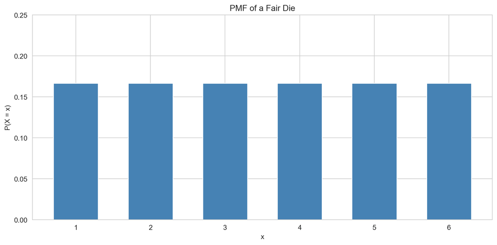

Probability mass function of a uniform random variable representing a fair dice

## Probability Density Functions

### Continuous distributions

**Probability Density Function (PDF)**

The **PDF** of a continuous random variable $X$ is a function $f(x) \geq 0$ such that:
$$P(a \leq X \leq b) = \int_a^b f(x)\, dx.$$

### Properties

- $f(x) \geq 0$ for all $x$.
- $\displaystyle\int_{-\infty}^{\infty} f(x)\, dx = 1$.
- For a continuous random variable: $P(X = x) = 0$ for any single point $x$.
  - Probabilities are **areas** under the curve, not heights.

## Example: Waiting times

- Consider a bus service that arrives every 30 minutes at a stop. A person arrives at the stop but they do not know the time.
- Define the random variable $Y$ to describe the waiting times of such a person:
  - The support is $x\in[0,30]$.
  - All waiting times in this interval are equally likely.
  - The PDF is:
    $$f(x)=\frac{1}{30},\quad \forall x\in[0,30].$$
  - This is an example of a continuous uniform distribution.

```python
x = np.linspace(0,30,1000)
y = np.ones(1000)/30
plt.plot(x, y)
plt.xlabel("x")
plt.ylabel("f(x)")
plt.title("Density plot for continuous uniform bus waiting times.")
plt.show()
```

## Example: Waiting times

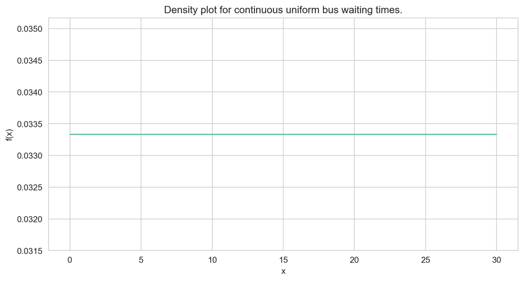

## Cumulative Distribution Function

**Cumulative Distribution Function (CDF)**

The **CDF** of a random variable $X$ is:
$$F(x) = P(X \leq x), \quad x \in \mathbb{R}.$$

### Properties

- $F$ is **non-decreasing**: $x_1 \leq x_2 \Rightarrow F(x_1) \leq F(x_2)$.
- $\lim_{x \to -\infty} F(x) = 0$ and $\lim_{x \to \infty} F(x) = 1$.
- For a continuous $X$: $f(x) = F'(x)$ (the PDF is the derivative of the CDF).

### Useful identity

$$P(a < X \leq b) = F(b) - F(a).$$

## Expectation

### Expected value of a random variable

**Expectation**

The **expectation** (or **mean**) of a random variable $X$ is:
$$\mathbb{E}[X] = \begin{cases} \displaystyle\sum_x x \cdot p(x) & \text{(discrete)} \\[6pt] \displaystyle\int_{-\infty}^{\infty} x \cdot f(x)\, dx & \text{(continuous).} \end{cases}$$

### Intuition

- $\mathbb{E}[X]$ is the **long-run average** value of $X$ over many independent repetitions of the experiment.

## Linearity of expectation

- For constants $a, b$ and random variables $X, Y$:
  $$\mathbb{E}[aX + bY] = a\,\mathbb{E}[X] + b\,\mathbb{E}[Y].$$
- This holds regardless of whether $X$ and $Y$ are **independent**.
- This property comes in handy in linear regression.

## Variance

### Measuring spread around the mean

**Variance**

The **variance** of a random variable $X$ is:
$$\text{Var}(X) = \mathbb{E}\!\left[(X - \mathbb{E}[X])^2\right] = \mathbb{E}[X^2] - \bigl(\mathbb{E}[X]\bigr)^2.$$

### Standard deviation

- The **standard deviation** is $\text{SD}(X) = \sqrt{\text{Var}(X)}$, which has the same units as $X$.

### Key properties

- $\text{Var}(aX + b) = a^2\,\text{Var}(X)$ (shifting does not affect spread; scaling does).
- For **independent** $X, Y$: $\text{Var}(X + Y) = \text{Var}(X) + \text{Var}(Y)$.

## Conditional Probability

### Updating probabilities with new information

**Conditional Probability**

The **conditional probability** of event $A$ given event $B$ (with $P(B) > 0$) is:
$$P(A \mid B) = \frac{P(A \cap B)}{P(B)}.$$

### Intuition

- $P(A \mid B)$ is the probability of $A$ **once we know** that $B$ has occurred — we restrict attention to the sub-universe where $B$ is true.

### Multiplication rule

$$P(A \cap B) = P(A \mid B)\, P(B) = P(B \mid A)\, P(A).$$

## Bayes’ Theorem

### Inverting conditional probabilities

**Bayes’ Theorem**

$$P(A \mid B) = \frac{P(B \mid A)\, P(A)}{P(B)}.$$

### Terminology in statistical modelling

- $P(A)$: **prior** — our belief about $A$ before observing $B$.
- $P(B \mid A)$: **likelihood** — how probable is $B$ if $A$ is true?
- $P(A \mid B)$: **posterior** — our updated belief after observing $B$.

### Why it matters

- Bayes’ theorem is the foundation of **Bayesian statistics** and many probabilistic classifiers (e.g. Naive Bayes).
- It formalises the idea of **learning from data**: updating beliefs in light of evidence.

## Independence

### When variables carry no information about each other

**Independence**

Events $A$ and $B$ are **independent** if:
$$P(A \cap B) = P(A)\, P(B), \quad \text{equivalently} \quad P(A \mid B) = P(A).$$

Random variables $X$ and $Y$ are **independent** if knowing the value of one provides **no information** about the other.

### Independence vs. uncorrelatedness

- **Independent** $\Rightarrow$ zero covariance (uncorrelated). The converse is **not** generally true.
- Recall from EDA: two variables can have correlation $\approx 0$ yet exhibit a strong non-linear relationship.

## Conditional Expectation

### Expected value given additional information

**Conditional Expectation**

The **conditional expectation** of $Y$ given $X = x$ is:
$$\mathbb{E}[Y \mid X = x] = \begin{cases} \displaystyle\sum_y y \cdot P(Y = y \mid X = x) & \text{(discrete)} \\[6pt] \displaystyle\int_{-\infty}^{\infty} y \cdot f_{Y \mid X}(y \mid x)\, dy & \text{(continuous).} \end{cases}$$

### Conditional expectation as a function

- $\mathbb{E}[Y \mid X]$ is itself a **random variable** — a function of $X$.
- In regression, $\mathbb{E}[Y \mid X = x]$ is the **regression function**: the best prediction of $Y$ given $X = x$.

## Conditional Expectation Properties

### Linearity of Conditional Expectation

$$\mathbb{E}[aX+bY|X] = aX + b\mathbb{E}[Y|X].$$

### Law of Total Expectation

$$\mathbb{E}[Y] = \mathbb{E}\!\bigl[\mathbb{E}[Y \mid X]\bigr].$$

Averaging conditional expectations over $X$ recovers the unconditional mean.

## Joint and Marginal Distributions

### Describing multiple random variables together

**Joint Distribution**

The **joint distribution** of $(X, Y)$ describes the probability of all pairs of outcomes simultaneously.

- **Discrete**: $p(x, y) = P(X = x,\, Y = y)$.
- **Continuous**: $f(x, y)$ such that $P\!\bigl((X, Y) \in A\bigr) = \iint_A f(x, y)\, dx\, dy$.

### Marginal distributions

The **marginal distribution** of $X$ is obtained by integrating (or summing) out $Y$:

- **Discrete**: $p_X(x) = \displaystyle\sum_y p(x, y)$.
- **Continuous**: $f_X(x) = \displaystyle\int_{-\infty}^{\infty} f(x, y)\, dy$.

### Conditional distribution

$$f_{Y \mid X}(y \mid x) = \frac{f(x, y)}{f_X(x)}, \quad f_X(x) > 0.$$

# Standard Distributions

## 📊 The Binomial Distribution

### Counting successes in repeated trials

**Binomial Distribution**

If $X$ counts the number of **successes** in $n$ independent **Bernoulli trials**, each with success probability $p$, then $X \sim \text{Binomial}(n, p)$ with PMF:
$$P(X = k) = \binom{n}{k} p^k (1-p)^{n-k}, \quad k = 0, 1, \ldots, n.$$

### Mean and variance

$$\mathbb{E}[X] = np, \qquad \text{Var}(X) = np(1-p).$$

### Applications in data science

- Modelling **click-through rates**, **defect counts**, **disease incidence**.
- Foundation for **logistic regression** (modelling binary outcomes).

## Binomial Distribution in Python

```python
fig, axes = plt.subplots(1, 3, figsize=(14, 4), sharey=False)
params = [(10, 0.3), (10, 0.5), (20, 0.7)]

for ax, (n, p) in zip(axes, params):
    k = np.arange(0, n + 1)
    ax.bar(k, binom.pmf(k, n, p), color='steelblue', edgecolor='white', width=0.6)
    ax.axvline(n * p, color='crimson', linestyle='--', label=f'Mean = {n*p:.1f}')
    ax.set_title(f'Binomial(n={n}, p={p})')
    ax.set_xlabel('k'); ax.set_ylabel('P(X = k)')
    ax.legend(fontsize=9)

plt.tight_layout()
plt.show()
```

## Binomial Distribution in Python

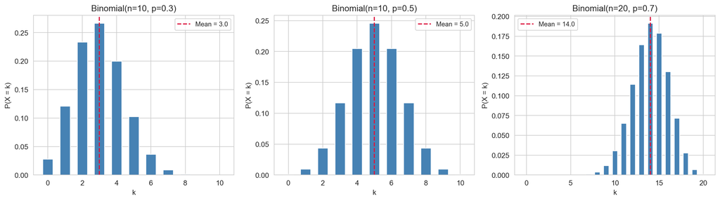

PMFs of the Binomial distribution for different parameter values.

## 📊 The Gaussian (Normal) Distribution

### The most important continuous distribution

**Gaussian (Normal) Distribution**

A random variable $X \sim \text{Normal}(\mu, \sigma^2)$ has PDF:
$$f(x) = \frac{1}{\sqrt{2\pi\sigma^2}} \exp\!\left(-\frac{(x-\mu)^2}{2\sigma^2}\right), \quad x \in \mathbb{R}.$$

### Mean and variance

$$\mathbb{E}[X] = \mu, \qquad \text{Var}(X) = \sigma^2.$$

### Why the Gaussian is everywhere

- **Central Limit Theorem**: the standardised sum of many i.i.d. random variables converges in distribution to $\text{Normal}(0,1)$.
- Many natural phenomena (heights, measurement errors, noise) are approximately Gaussian.

## The Standard Normal and the 68-95-99.7 Rule

### Standardisation

- If $X \sim \text{Normal}(\mu, \sigma^2)$, then $Z = \dfrac{X - \mu}{\sigma} \sim \text{Normal}(0, 1)$ is the **standard normal**.

### The 68-95-99.7 Rule

- $P(\mu - \sigma \leq X \leq \mu + \sigma) \approx 0.68$
- $P(\mu - 2\sigma \leq X \leq \mu + 2\sigma) \approx 0.95$
- $P(\mu - 3\sigma \leq X \leq \mu + 3\sigma) \approx 0.997$

### Connecting to EDA

- We introduced the normal distribution in Lecture 6 to interpret **skewness** and **kurtosis** — a distribution is symmetric and mesokurtic when it is Gaussian.

## Gaussian Distribution in Python

```python
fig, axes = plt.subplots(1, 2, figsize=(14, 5))

# Left: varying parameters
x = np.linspace(-7, 7, 500)
for mu, sigma, color, label in [(0, 1, 'steelblue', 'μ=0, σ=1'),
                                  (0, 2, 'crimson',   'μ=0, σ=2'),
                                  (2, 1, 'seagreen',  'μ=2, σ=1')]:
    axes[0].plot(x, norm.pdf(x, mu, sigma), color=color, lw=2, label=label)
axes[0].set_title('Normal Distributions')
axes[0].set_xlabel('x'); axes[0].set_ylabel('f(x)')
axes[0].legend()

# Right: 68-95-99.7 rule
x2 = np.linspace(-4, 4, 500)
axes[1].plot(x2, norm.pdf(x2), 'k', lw=2)
for n_sig, color, label in [(3, '#d0e8ff', '±3σ  (99.7%)'),
                              (2, '#85b9f5', '±2σ  (95%)'),
                              (1, '#2f6fbd', '±1σ  (68%)')]:
    xf = np.linspace(-n_sig, n_sig, 300)
    axes[1].fill_between(xf, norm.pdf(xf), alpha=0.65, color=color, label=label)
axes[1].set_title('68-95-99.7 Rule')
axes[1].set_xlabel('x'); axes[1].set_ylabel('f(x)')
axes[1].legend()

plt.tight_layout()
plt.show()
```

## Gaussian Distribution in Python

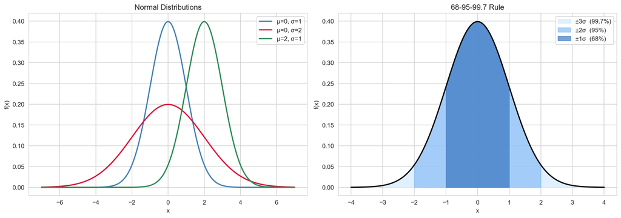

Normal PDFs with different parameters (left) and the 68-95-99.7 rule (right).

## 📊 The Multivariate Gaussian Distribution

### Extending the Normal to multiple dimensions

**Multivariate Gaussian Distribution**

A random vector $\mathbf{X} = (X_1, \ldots, X_d)^\top \sim \text{Normal}(\boldsymbol{\mu}, \boldsymbol{\Sigma})$ has PDF:
$$f(\mathbf{x}) = \frac{1}{(2\pi)^{d/2} |\boldsymbol{\Sigma}|^{1/2}} \exp\!\left(-\frac{1}{2}(\mathbf{x} - \boldsymbol{\mu})^\top \boldsymbol{\Sigma}^{-1} (\mathbf{x} - \boldsymbol{\mu})\right),$$
where $\boldsymbol{\mu} \in \mathbb{R}^d$ is the **mean vector** and $\boldsymbol{\Sigma} \in \mathbb{R}^{d \times d}$ is the **covariance matrix** (symmetric, positive semi-definite).

### Parameters

- $\mathbb{E}[\mathbf{X}] = \boldsymbol{\mu}$: the mean of each component.
- $\text{Cov}(X_i, X_j) = \Sigma_{ij}$: off-diagonal entries capture linear co-movement; diagonal entries are variances $\sigma_i^2$.
- When $\boldsymbol{\Sigma}$ is diagonal, the components are **uncorrelated** (and, for Gaussians, independent).

## Multivariate Gaussian in Python

```python
fig, axes = plt.subplots(1, 3, figsize=(15, 4))
configs = [
    {'title': 'Independent\n(Σ = I)',          'cov': [[1,    0   ], [0,    1   ]]},
    {'title': 'Positive correlation\n(ρ = 0.8)', 'cov': [[1,    0.8 ], [0.8,  1   ]]},
    {'title': 'Negative correlation\n(ρ = −0.8)', 'cov': [[1,   -0.8 ], [-0.8, 1   ]]},
]
x1, x2 = np.mgrid[-3:3:0.05, -3:3:0.05]
pos = np.dstack((x1, x2))

for ax, cfg in zip(axes, configs):
    rv = multivariate_normal(mean=[0, 0], cov=cfg['cov'])
    ax.contourf(x1, x2, rv.pdf(pos), levels=15, cmap='Blues')
    ax.set_title(cfg['title'])
    ax.set_xlabel('$X_1$'); ax.set_ylabel('$X_2$')

plt.tight_layout()
plt.show()
```

- The shape of the contours reflects the **covariance structure**: circular for independence, elliptical for correlated components.
- The MVN is the building block of **multivariate regression**, **Gaussian processes**, and **PCA**.

## Multivariate Gaussian in Python

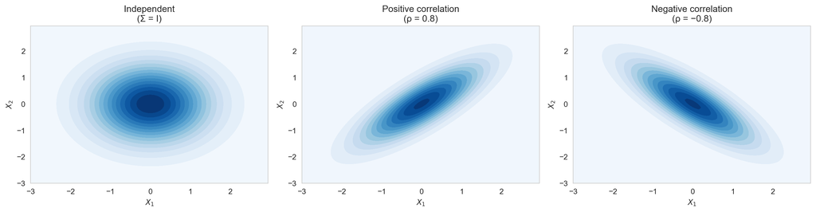

Bivariate Gaussian densities with different covariance structures.

## Other Important Distributions

### Discrete distributions

- **Bernoulli$(p)$**: single binary trial; $P(X=1) = p$. Special case of Binomial($n=1$, $p$).
- **Poisson$(\lambda)$**: counts events in a fixed interval; $P(X=k) = e^{-\lambda}\lambda^k / k!$. Mean = Variance = $\lambda$.
- **Geometric$(p)$**: number of trials until the first success.

### Continuous distributions

- **Uniform$(a,b)$**: equal density across $[a,b]$; $f(x) = \frac{1}{b-a}$.
- **Exponential$(\lambda)$**: time until first Poisson event; $f(x) = \lambda e^{-\lambda x}$, $x \geq 0$.
- **Beta$(\alpha, \beta)$**: supported on $[0,1]$; models probabilities; used extensively in Bayesian statistics.
- **Chi-squared, $t$, $F$**: arise as transformations of Gaussians; fundamental in classical hypothesis testing.

## Probability Theory: Summary

| Concept | Formula | Role in Modelling |
| --- | --- | --- |
| PMF / PDF | $p(x)$, $f(x)$ | Describes the distribution of $X$ |
| CDF | $F(x) = P(X \leq x)$ | Computes probabilities |
| Expectation | $\mathbb{E}[X]$ | Population mean |
| Variance | $\text{Var}(X) = \mathbb{E}[(X-\mathbb{E}X)^2]$ | Population spread |
| Conditional Prob. | $P(A \mid B) = P(A\cap B)/P(B)$ | Updating beliefs |
| Conditional Exp. | $\mathbb{E}[Y \mid X]$ | Regression function |
| Joint / Marginal | $f(x,y)$, $f_X(x)$ | Multivariate models |

## Conclusion

### ✅ What we covered

- **Introduction to modelling**: what models are and why we build them.
- **Model categories**: deterministic, probabilistic, statistical, and machine learning.
- **Probability theory** foundations:
  - Sample spaces, events, and the Kolmogorov axioms.
  - Random variables: discrete and continuous.
  - PMF, PDF, and CDF.
  - Expectation and variance.
  - Conditional probability and Bayes’ theorem.
  - Independence and conditional expectation.
  - Joint and marginal distributions.
  - Standard distributions: Binomial, Gaussian, Multivariate Gaussian.

### 📅 What’s next?

- Statistical inference.
- Estimation and hypothesis testing.